# Data Overview

```python
# Import libraries
import pandas as pd
import numpy as np
import matplotlib.pyplot as plt
import seaborn as sns
```

```python
exited_df_3 = pd.read_csv("Exited_Companies.csv", encoding='unicode_escape')
```

```python
emerging_df_3 = pd.read_csv("Emerging_Companies.csv", encoding='unicode_escape')
```

```python
existing_df_3 = pd.read_csv("Unicorn_Companies.csv", encoding='unicode_escape')
```

# EDA

### Preliminary EDA:

```
1. Generate a report detailing the data types of each column in the dataset.
2. Compute and display basic statistical summaries.
3. Identify any missing values in the dataset.
```

#### Exited Unicorn Companies

```python
exited_df_3.head(5)
```

|  | Organisation | Country | Industry | Main Industry | Month | Year | Exit Reason | Main Reason |
| --- | --- | --- | --- | --- | --- | --- | --- | --- |
| 0 | 10X Genomics | United States | BioSoftware & Technology, Genetics, Health Car... | Healthcare & BioTechnology | September | 2019 | Bankrupt | Bankrupt |
| 1 | 17zuoye | China | E-Learning, EdTech, Education, Internet, Langu... | Education and EdTech | December | 2020 | Bankrupt | Bankrupt |
| 2 | 23andMe | United States | BioSoftware & Technology, Genetics, Life Science | Healthcare & BioTechnology | June | 2021 | SPAC merger | Merger |
| 3 | 51 Credit Card Manager | China | Credit Cards, Finance, Financial Services, Fin... | Finance and FinTech | July | 2018 | Bankrupt | Bankrupt |
| 4 | 9F Group | China | Financial Services, FinTech | Finance and FinTech | August | 2019 | IPO | IPO |

```python
# Display data types of each column
data_types_report = exited_df_3.dtypes

# Count the number of categorical and numerical columns
categorical_columns = exited_df_3.select_dtypes(include='object').columns
numerical_columns = exited_df_3.select_dtypes(exclude='object').columns

num_categorical_columns = len(categorical_columns)
num_numerical_columns = len(numerical_columns)

# Print the report
print("Data Types Report:")
print(data_types_report)
print("\nNumber of Categorical Columns:", num_categorical_columns)
print("Number of Numerical Columns:", num_numerical_columns)
```

```
Data Types Report:
Organisation     object
Country          object
Industry         object
Main Industry    object
Month            object
Year              int64
Exit Reason      object
Main Reason      object
dtype: object

Number of Categorical Columns: 7
Number of Numerical Columns: 1
```

```python
exited_df_3.describe()
```

|  | Year |
| --- | --- |
| count | 468.000000 |
| mean | 2019.506410 |
| std | 2.595904 |
| min | 2006.000000 |
| 25% | 2018.000000 |
| 50% | 2020.000000 |
| 75% | 2021.000000 |
| max | 2023.000000 |

```python
print(exited_df_3.isnull().sum())
```

```
Organisation     0
Country          0
Industry         0
Main Industry    0
Month            0
Year             0
Exit Reason      0
Main Reason      0
dtype: int64
```

#### Emerging Unicorn Companies

```python
emerging_df_3.head(5)
```

|  | Company | Post Money Value | Total Equity Funding | Lead Investors Include | Country | Continent |
| --- | --- | --- | --- | --- | --- | --- |
| 0 | C2x | 500 | 25 | Galaxy Interactive, Agnitio Capital | United States | North America |
| 1 | SEON | 500 | 108 | IVP | Hungary | Europe |
| 2 | Envisics | 500 | 150 | M&G Investments | United Kingdom | Europe |
| 3 | Porter | 500 | 132 | Tiger Global Management, Vitruvian Partners | India | Asia |
| 4 | FINN | 500 | 144 | Korelya Capital | Germany | Europe |

```python
# Display data types of each column
data_types_report = emerging_df_3.dtypes

# Count the number of categorical and numerical columns
categorical_columns = emerging_df_3.select_dtypes(include='object').columns
numerical_columns = emerging_df_3.select_dtypes(exclude='object').columns

num_categorical_columns = len(categorical_columns)
num_numerical_columns = len(numerical_columns)

# Print the report
print("Data Types Report:")
print(data_types_report)
print("\nNumber of Categorical Columns:", num_categorical_columns)
print("Number of Numerical Columns:", num_numerical_columns)
```

```
Data Types Report:
Company                   object
Post Money Value           int64
Total Equity Funding       int64
Lead Investors Include    object
Country                   object
Continent                 object
dtype: object

Number of Categorical Columns: 4
Number of Numerical Columns: 2
```

```python
emerging_df_3.describe()
```

|  | Post Money Value | Total Equity Funding |
| --- | --- | --- |
| count | 380.000000 | 380.000000 |
| mean | 679.610526 | 174.126316 |
| std | 142.431045 | 113.012339 |
| min | 500.000000 | 0.000000 |
| 25% | 550.000000 | 108.000000 |
| 50% | 673.500000 | 152.500000 |
| 75% | 800.000000 | 214.250000 |
| max | 986.000000 | 935.000000 |

```python
print(emerging_df_3.isnull().sum())
```

```
Company                   0
Post Money Value          0
Total Equity Funding      0
Lead Investors Include    0
Country                   0
Continent                 0
dtype: int64
```

#### Existing Unicorn Companies

```python
existing_df_3.head(5)
```

|  | Company | Post Money Value | Total Equity Funding | Lead Investors Include | Country | Continent | Month | Year | Industry |
| --- | --- | --- | --- | --- | --- | --- | --- | --- | --- |
| 0 | Reliance Jio | 58 | 20000.0 | Google | India | Asia | NaN | NaN | Enterprise Tech |
| 1 | Ant Group | 150 | 19000.0 | GIC, Temasek Holdings | China | Asia | 1.0 | 2014.0 | Financial Services |
| 2 | JUUL | 38 | 14000.0 | Altria | United States | North America | 12.0 | 2017.0 | Consumer & Retail |
| 3 | OpenAI | 29 | 11000.0 | Microsoft | United States | North America | 7.0 | 2019.0 | Enterprise Tech |
| 4 | SpaceX | 125 | 9000.0 | Mirae Asset Venture Investment | United States | North America | 12.0 | 2012.0 | Industrials |

```python
# Display data types of each column
data_types_report = existing_df_3.dtypes

# Count the number of categorical and numerical columns
categorical_columns = existing_df_3.select_dtypes(include='object').columns
numerical_columns = existing_df_3.select_dtypes(exclude='object').columns

num_categorical_columns = len(categorical_columns)
num_numerical_columns = len(numerical_columns)

# Print the report
print("Data Types Report:")
print(data_types_report)
print("\nNumber of Categorical Columns:", num_categorical_columns)
print("Number of Numerical Columns:", num_numerical_columns)
```

```
Data Types Report:
Company                    object
Post Money Value            int64
Total Equity Funding      float64
Lead Investors Include     object
Country                    object
Continent                  object
Month                     float64
Year                      float64
Industry                   object
dtype: object

Number of Categorical Columns: 5
Number of Numerical Columns: 4
```

```python
existing_df_3.describe()
```

|  | Post Money Value | Total Equity Funding | Month | Year |
| --- | --- | --- | --- | --- |
| count | 1490.000000 | 1490.000000 | 1186.000000 | 1187.000000 |
| mean | 3.344295 | 601.034724 | 6.266442 | 2020.336142 |
| std | 9.108936 | 1149.107317 | 3.381484 | 1.964886 |
| min | 1.000000 | 0.000000 | 1.000000 | 2007.000000 |
| 25% | 1.000000 | 206.000000 | 3.000000 | 2020.000000 |
| 50% | 2.000000 | 355.500000 | 6.000000 | 2021.000000 |
| 75% | 3.000000 | 614.750000 | 9.000000 | 2022.000000 |
| max | 220.000000 | 20000.000000 | 12.000000 | 2023.000000 |

```python
print(existing_df_3.isnull().sum())
```

```
Company                     0
Post Money Value            0
Total Equity Funding        0
Lead Investors Include      0
Country                     0
Continent                   0
Month                     304
Year                      303
Industry                   67
dtype: int64
```

### Univariate Analysis:

```
1. Plot histograms for all numerical columns in the dataset.
2. For each categorical column, generate bar plots depicting the frequency of each category.
```

#### Exited Unicorn Companies

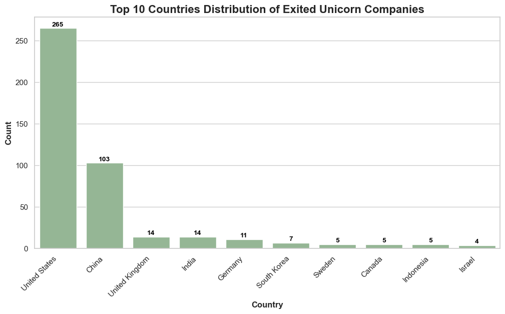

```python
# Assuming you want to plot a count of each country in a column called 'Top Countries'
top_countries = exited_df_3['Country'].value_counts().nlargest(10).index

# Filter the dataframe to include only the top 10 countires
df_top_countries = exited_df_3[exited_df_3['Country'].isin(top_countries)]

# Create a bar chart
plt.figure(figsize=(12, 6))
sns.set(style="whitegrid")  # Set the style of the plot

ax = sns.countplot(data=df_top_countries, x='Country', color="darkseagreen", order=top_countries)

plt.title('Top 10 Countries Distribution of Exited Unicorn Companies', fontsize=16, fontweight='bold')
plt.xlabel('Country', fontsize=12, fontweight='bold')
plt.ylabel('Count', fontsize=12, fontweight='bold')

plt.xticks(rotation=45, ha='right')  # Rotate x-axis labels for better visibility

# Add counts to the bars
for p in ax.patches:
    ax.annotate(f'{p.get_height()}', (p.get_x() + p.get_width() / 2., p.get_height()),
                ha='center', va='center', fontsize=10, color='black', fontweight='bold', xytext=(0, 5),
                textcoords='offset points')

plt.show()
```

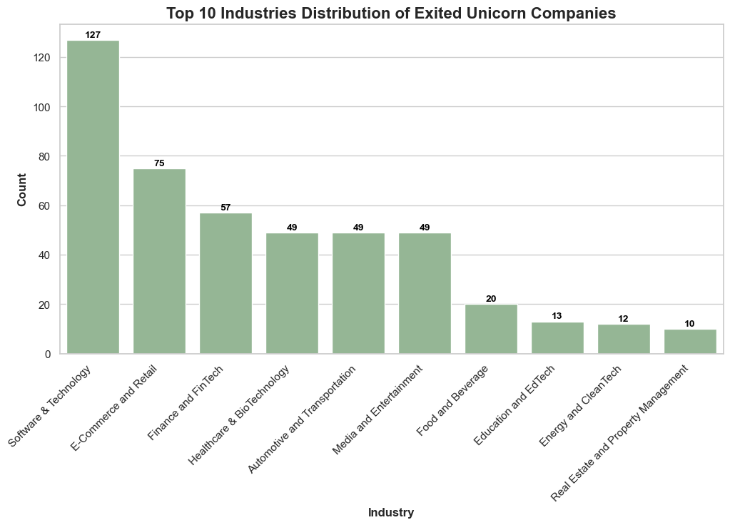

```python
# Assuming you want to plot a count of each industry in a column called 'Top Industries'
top_industries = exited_df_3['Main Industry'].value_counts().nlargest(10).index

# Filter the dataframe to include only the top 10 industries
df_top_industries = exited_df_3[exited_df_3['Main Industry'].isin(top_industries)]

# Create a bar chart
plt.figure(figsize=(12, 6))
sns.set(style="whitegrid")  # Set the style of the plot

ax = sns.countplot(data=df_top_industries, x='Main Industry', color="darkseagreen", order=top_industries)

plt.title('Top 10 Industries Distribution of Exited Unicorn Companies', fontsize=16, fontweight='bold')
plt.xlabel('Industry', fontsize=12, fontweight='bold')
plt.ylabel('Count', fontsize=12, fontweight='bold')

plt.xticks(rotation=45, ha='right')  # Rotate x-axis labels for better visibility

# Add counts to the bars
for p in ax.patches:
    ax.annotate(f'{p.get_height()}', (p.get_x() + p.get_width() / 2., p.get_height()),
                ha='center', va='center', fontsize=10, color='black', fontweight='bold', xytext=(0, 5),
                textcoords='offset points')

plt.show()
```

The majority of unicorn companies that have exited are in the software and technology industries. The Software and Technology industry accounts for 27% of all companies.

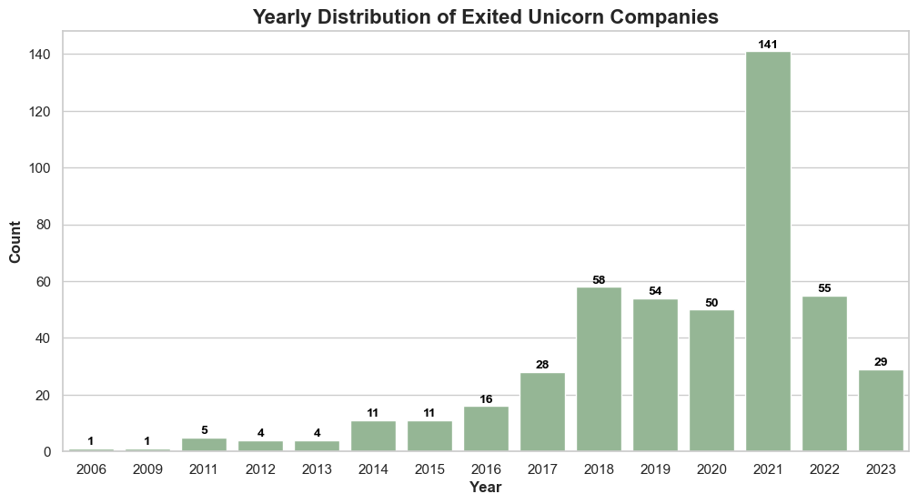

```python
# Create a bar chart
plt.figure(figsize=(12, 6))
sns.set(style="whitegrid")  # Set the style of the plot

# Assuming you want to plot a count of each yeah in a column called 'Year'
ax = sns.countplot(data=exited_df_3, x='Year', color="darkseagreen")

plt.title('Yearly Distribution of Exited Unicorn Companies', fontsize=16, fontweight='bold')
plt.xlabel('Year', fontsize=12, fontweight='bold')
plt.ylabel('Count', fontsize=12, fontweight='bold')

# Add counts to the bars
for p in ax.patches:
    ax.annotate(f'{p.get_height()}', (p.get_x() + p.get_width() / 2., p.get_height()),
                ha='center', va='center', fontsize=10, color='black', fontweight='bold', xytext=(0, 5),
                textcoords='offset points')

plt.show()
```

According to the graph, the majority of companies were exited in 2021, with the fewest companies exiting in 2006 and 2009. From 2018 to 2020, the number of exited companies decreased, but it increased dramatically in 2021. After 2021 it has decreased yearly.

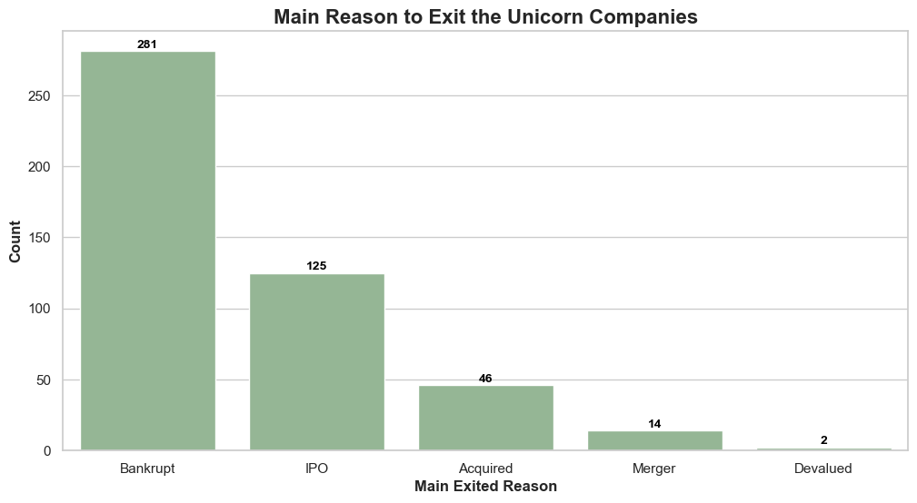

```python
# Assuming you want to plot a count of each reason in a column called 'Exited Reasons'
exited_df_3_sorted = exited_df_3['Main Reason'].value_counts().sort_values(ascending=False).index

plt.figure(figsize=(12, 6))
sns.set(style="whitegrid")  # Set the style of the plot

# Use the sorted order for the x-axis
ax = sns.countplot(data=exited_df_3, x='Main Reason', order=exited_df_3_sorted, color="darkseagreen")

plt.title('Main Reason to Exit the Unicorn Companies', fontsize=16, fontweight='bold')
plt.xlabel('Main Exited Reason', fontsize=12, fontweight='bold')
plt.ylabel('Count', fontsize=12, fontweight='bold')

# Add counts to the bars
for p in ax.patches:
    ax.annotate(f'{p.get_height()}', (p.get_x() + p.get_width() / 2., p.get_height()),
                ha='center', va='center', fontsize=10, color='black', fontweight='bold', xytext=(0, 5),
                textcoords='offset points')

plt.show()
```

Based on the chart, the majority of the companies were shut down due to bankruptcy. The least amount of businesses have left due to devaluation.

#### Emerging Unicorn Companies

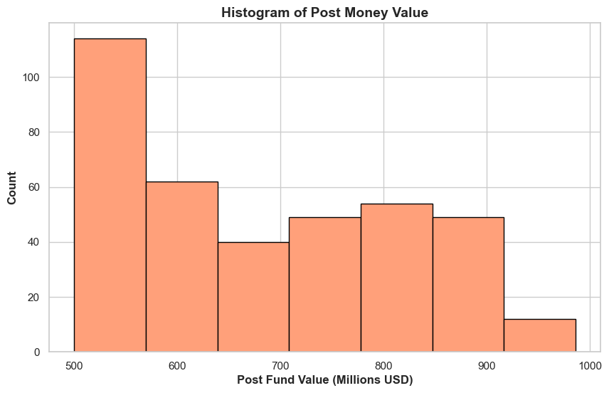

```python
# Create a histogram for Post Money Value
plt.figure(figsize=(10, 6))
plt.hist(emerging_df_3['Post Money Value'], bins=7, color='lightsalmon', edgecolor='black')
plt.title('Histogram of Post Money Value', fontsize=14, fontweight='bold')
plt.xlabel('Post Fund Value (Millions USD)', fontsize=12, fontweight='bold')
plt.ylabel('Count', fontsize=12, fontweight='bold')
plt.show()
```

Stating that a company named "Coro" had a valuation recorded as 0.298 Millions in our dataset. However, we believe that it is an outlier because an emerging Unicorn will always have a valuation above $500. So, we removed it for a more effective analysis

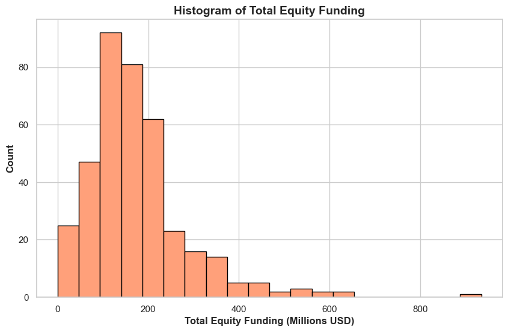

```python
# Create a histogram for Total Equity Funding
plt.figure(figsize=(10, 6))
plt.hist(emerging_df_3['Total Equity Funding'], bins=20, color='lightsalmon', edgecolor='black')
plt.title('Histogram of Total Equity Funding', fontsize=14, fontweight='bold')
plt.xlabel('Total Equity Funding (Millions USD)', fontsize=12, fontweight='bold')
plt.ylabel('Count', fontsize=12, fontweight='bold')
plt.show()
```

According to the histogram, the majority of the companies' total equity funding ranges from 0 to 200 million. There is one company that has received over 800 million total equity funding. Despite being an outlier, it is acceptable. There may be companies with a total equity fund of more than 800 million.

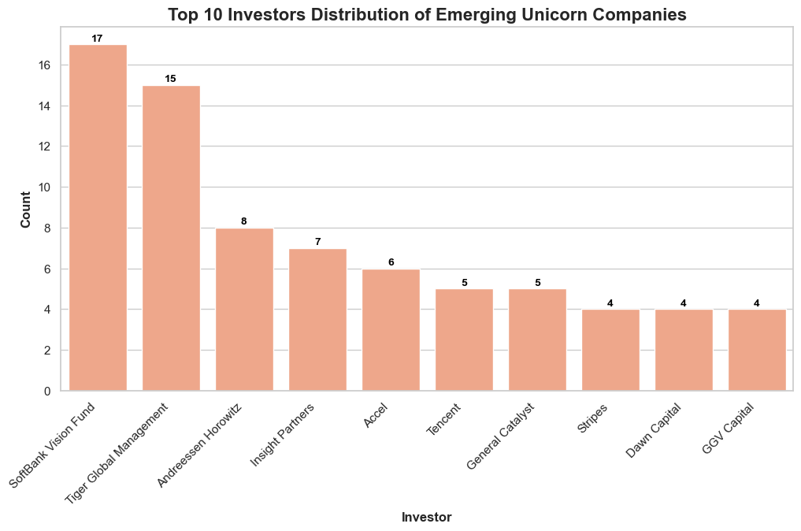

```python
# Split the values in the column by commas and strip whitespaces
emerging_df_3['Lead Investors Include'] = emerging_df_3['Lead Investors Include'].str.split(',').apply(lambda x: [i.strip() for i in x])

# Create a new DataFrame to store the comma-separated data
df_split = pd.DataFrame(emerging_df_3['Lead Investors Include'].tolist(), index=emerging_df_3.index).stack().reset_index(level=1, drop=True).reset_index(name='split_values')

# Count the unique values in the column
unique_values_count = df_split['split_values'].value_counts()

# Assuming you want to plot a count of each investor in a column called 'Top Investors'
top_investors = df_split['split_values'].value_counts().nlargest(10).index

# Filter the dataframe to include only the top 10 investors
df_top_investors = df_split[df_split['split_values'].isin(top_investors)]

# Create a bar chart
plt.figure(figsize=(12, 6))
sns.set(style="whitegrid")  # Set the style of the plot

ax = sns.countplot(data=df_top_investors, x='split_values', color="lightsalmon", order=top_investors)

plt.title('Top 10 Investors Distribution of Emerging Unicorn Companies', fontsize=16, fontweight='bold')
plt.xlabel('Investor', fontsize=12, fontweight='bold')
plt.ylabel('Count', fontsize=12, fontweight='bold')

plt.xticks(rotation=45, ha='right')  # Rotate x-axis labels for better visibility

# Add counts to the bars
for p in ax.patches:
    ax.annotate(f'{p.get_height()}', (p.get_x() + p.get_width() / 2., p.get_height()),
                ha='center', va='center', fontsize=10, color='black', fontweight='bold', xytext=(0, 5),
                textcoords='offset points')

plt.show()
```

According to the above bar chart, SoftBank Vision Fund invests in the majority of emerging unicorn companies. Tiger Global Management is the second largest investor in emerging unicorns.

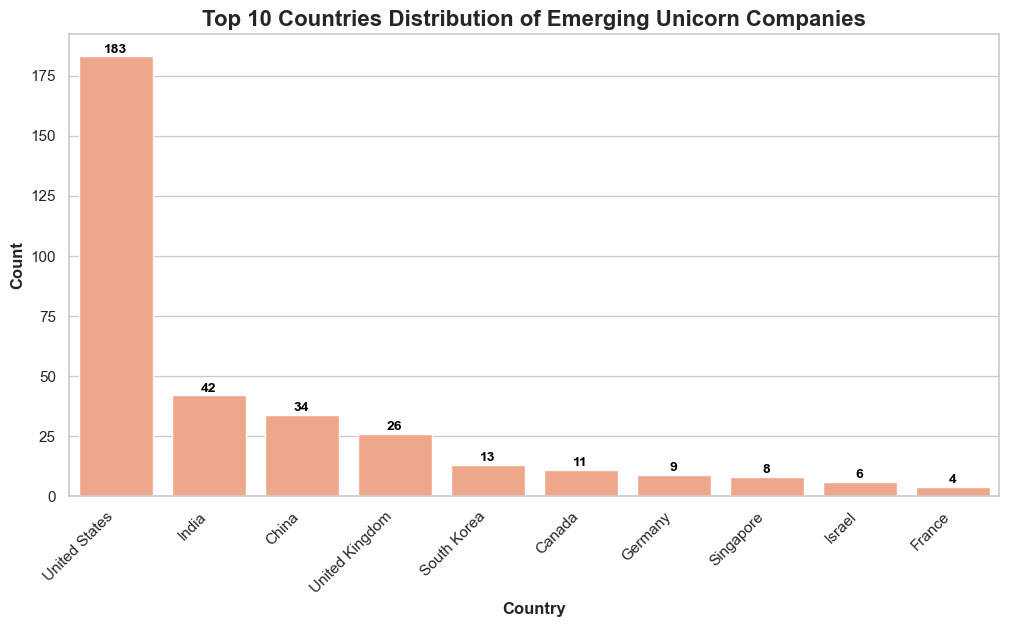

```python
# Assuming you want to plot a count of each country in a column called 'Top Countries'
top_countries = emerging_df_3['Country'].value_counts().nlargest(10).index

# Filter the dataframe to include only the top 10 countries
df_top_countries = emerging_df_3[emerging_df_3['Country'].isin(top_countries)]

# Create a bar chart
plt.figure(figsize=(12, 6))
sns.set(style="whitegrid")  # Set the style of the plot

ax = sns.countplot(data=df_top_countries, x='Country', color="lightsalmon", order=top_countries)

plt.title('Top 10 Countries Distribution of Emerging Unicorn Companies', fontsize=16, fontweight='bold')
plt.xlabel('Country', fontsize=12, fontweight='bold')
plt.ylabel('Count', fontsize=12, fontweight='bold')

plt.xticks(rotation=45, ha='right')  # Rotate x-axis labels for better visibility

# Add counts to the bars
for p in ax.patches:
    ax.annotate(f'{p.get_height()}', (p.get_x() + p.get_width() / 2., p.get_height()),
                ha='center', va='center', fontsize=10, color='black', fontweight='bold', xytext=(0, 5),
                textcoords='offset points')

plt.show()
```

According to the above bar chart, the majority of emerging unicorn companies are based in the United States. When compared to the other companies, the United States has a significant advantage.

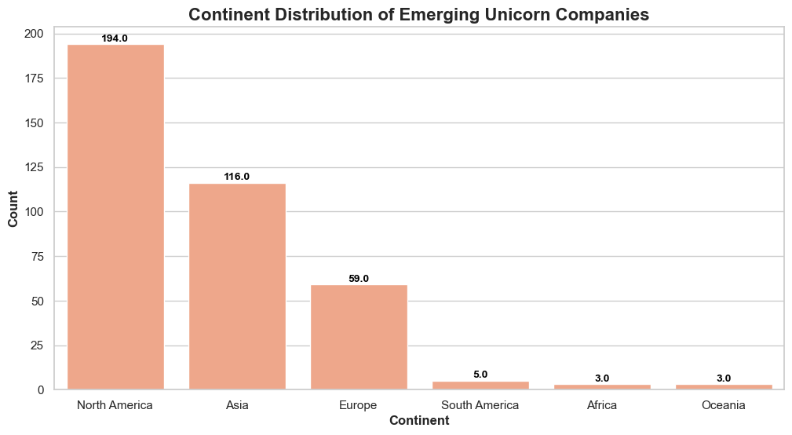

```python
# Sort the data by count in descending order
sorted_df = emerging_df_3['Continent'].value_counts().reset_index().rename(columns={'index': 'Continent', 'Continent': 'Count'})
sorted_df = sorted_df.sort_values(by='Count', ascending=False)

# Create a bar chart
plt.figure(figsize=(12, 6))
sns.set(style="whitegrid")  # Set the style of the plot

ax = sns.barplot(data=sorted_df, x='Continent', y='Count', color="lightsalmon")

plt.title('Continent Distribution of Emerging Unicorn Companies', fontsize=16, fontweight='bold')
plt.xlabel('Continent', fontsize=12, fontweight='bold')
plt.ylabel('Count', fontsize=12, fontweight='bold')

# Add counts to the bars
for p in ax.patches:
    ax.annotate(f'{p.get_height()}', (p.get_x() + p.get_width() / 2., p.get_height()),
                ha='center', va='center', fontsize=10, color='black', fontweight='bold', xytext=(0, 5),
                textcoords='offset points')

plt.show()
```

#### Existing Unicorn Companies

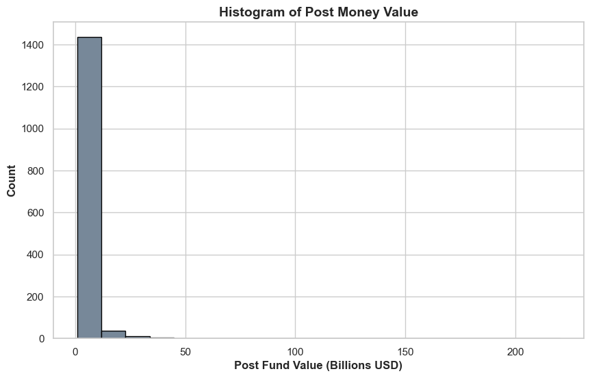

```python
# Create a histogram for Post Money Value
plt.figure(figsize=(10, 6))
plt.hist(existing_df_3['Post Money Value'], bins=20, color='lightslategrey', edgecolor='black')
plt.title('Histogram of Post Money Value', fontsize=14, fontweight='bold')
plt.xlabel('Post Fund Value (Billions USD)', fontsize=12, fontweight='bold')
plt.ylabel('Count', fontsize=12, fontweight='bold')
plt.show()
```

The histogram above shows that the post-fund value of almost all existing unicorn companies ranges from 1 billion to 50 billion. There are six unicorn companies with post-fund valuations of more than $50 billion. As a result, the histogram is skewed to the right.

1. ByteDance - $220B
2. Ant Group - $150B
3. SpaceX - $125B
4. Reliance Retail - $100B
5. Shein - $66B
6. Reliance Jio - $58B

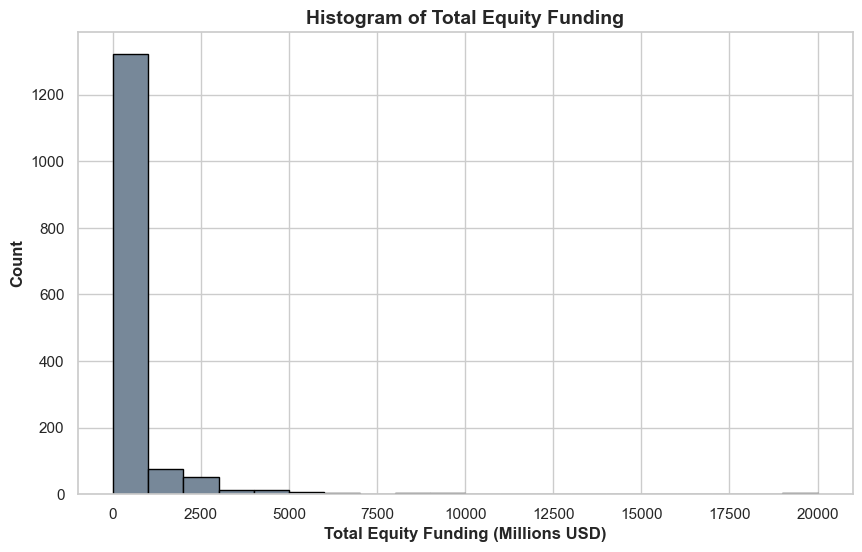

```python
# Create a histogram for Total Equity Funding
plt.figure(figsize=(10, 6))
plt.hist(existing_df_3['Total Equity Funding'], bins=20, color='lightslategrey', edgecolor='black')
plt.title('Histogram of Total Equity Funding', fontsize=14, fontweight='bold')
plt.xlabel('Total Equity Funding (Millions USD)', fontsize=12, fontweight='bold')
plt.ylabel('Count', fontsize=12, fontweight='bold')
plt.show()
```

According to the histogram, the majority of existing companies' total equity funding ranges from 0 to 2500 million. The histogram is skewed to the right because 12 companies got more than 5000 million in total equity funding.

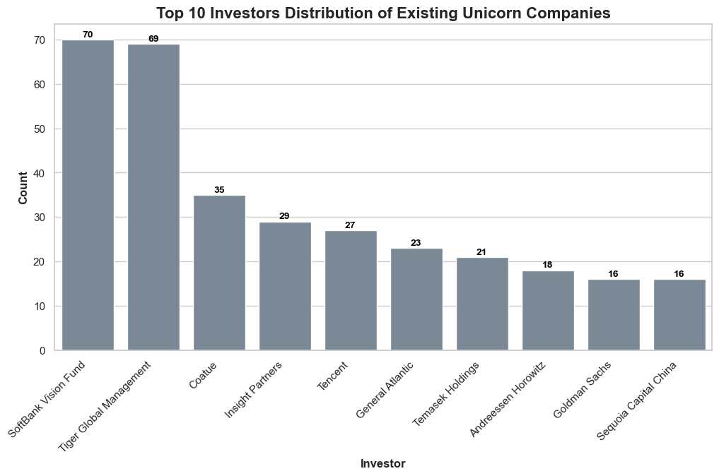

```python
# Split the values in the column by commas and strip whitespaces
existing_df_3['Lead Investors Include'] = existing_df_3['Lead Investors Include'].str.split(',').apply(lambda x: [i.strip() for i in x])

# Create a new DataFrame to store the comma-separated data
df_split_existing = pd.DataFrame(existing_df_3['Lead Investors Include'].tolist(), index=existing_df_3.index).stack().reset_index(level=1, drop=True).reset_index(name='split_values')

# Count the unique values in the column
unique_values_count_existing = df_split_existing['split_values'].value_counts()

# Assuming you want to plot a count of each investor in a column called 'Top Ivestors'
top_investors_existing = df_split_existing['split_values'].value_counts().nlargest(10).index

# Filter the dataframe to include only the top 10 investors
df_top_investors_existing = df_split_existing[df_split_existing['split_values'].isin(top_investors_existing)]

# Create a bar chart
plt.figure(figsize=(12, 6))
sns.set(style="whitegrid")  # Set the style of the plot

ax = sns.countplot(data=df_top_investors_existing, x='split_values', color="lightslategrey", order=top_investors_existing)

plt.title('Top 10 Investors Distribution of Existing Unicorn Companies', fontsize=16, fontweight='bold')
plt.xlabel('Investor', fontsize=12, fontweight='bold')
plt.ylabel('Count', fontsize=12, fontweight='bold')

plt.xticks(rotation=45, ha='right')  # Rotate x-axis labels for better visibility

# Add counts to the bars
for p in ax.patches:
    ax.annotate(f'{p.get_height()}', (p.get_x() + p.get_width() / 2., p.get_height()),
                ha='center', va='center', fontsize=10, color='black', fontweight='bold', xytext=(0, 5),
                textcoords='offset points')

plt.show()
```

According to the bar chart, SoftBank Vision Fund is an investor in many existing unicorn companies. The second largest investor is Tiger Global Management.

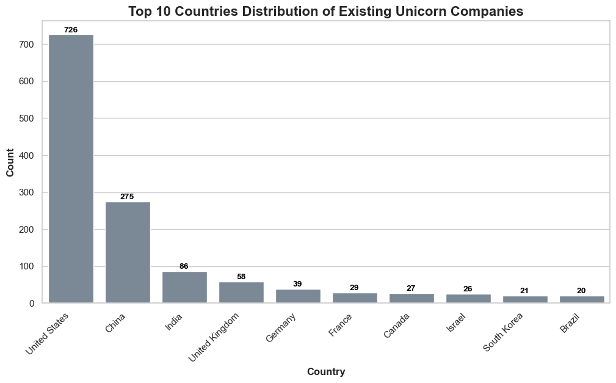

```python
# Assuming you want to plot a count of each country in a column called 'Top Countries'
top_countries = existing_df_3['Country'].value_counts().nlargest(10).index

# Filter the dataframe to include only the top 10 countries
df_top_countries = existing_df_3[existing_df_3['Country'].isin(top_countries)]

# Create a bar chart
plt.figure(figsize=(12, 6))
sns.set(style="whitegrid")  # Set the style of the plot

ax = sns.countplot(data=df_top_countries, x='Country', color="lightslategrey", order=top_countries)

plt.title('Top 10 Countries Distribution of Existing Unicorn Companies', fontsize=16, fontweight='bold')
plt.xlabel('Country', fontsize=12, fontweight='bold')
plt.ylabel('Count', fontsize=12, fontweight='bold')

plt.xticks(rotation=45, ha='right')  # Rotate x-axis labels for better visibility

# Add counts to the bars
for p in ax.patches:
    ax.annotate(f'{p.get_height()}', (p.get_x() + p.get_width() / 2., p.get_height()),
                ha='center', va='center', fontsize=10, color='black', fontweight='bold', xytext=(0, 5),
                textcoords='offset points')

plt.show()
```

According to the above graph, the majority of existing unicron companies originated in the United States, with China ranking second largest country.

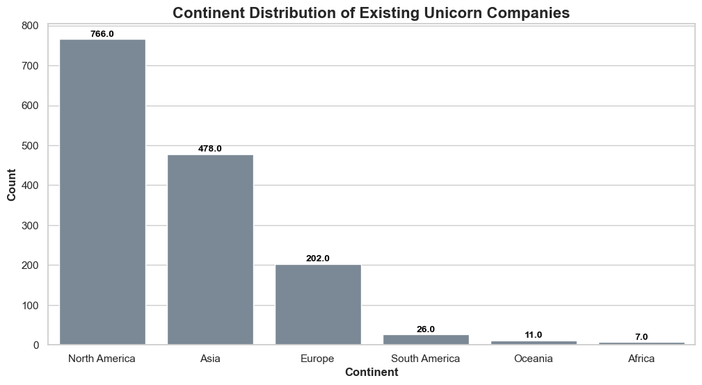

```python
# Sort the data by count in descending order
sorted_df = existing_df_3['Continent'].value_counts().reset_index().rename(columns={'index': 'Continent', 'Continent': 'Count'})
sorted_df = sorted_df.sort_values(by='Count', ascending=False)

# Create a bar chart
plt.figure(figsize=(12, 6))
sns.set(style="whitegrid")  # Set the style of the plot

ax = sns.barplot(data=sorted_df, x='Continent', y='Count', color="lightslategrey")

plt.title('Continent Distribution of Existing Unicorn Companies', fontsize=16, fontweight='bold')
plt.xlabel('Continent', fontsize=12, fontweight='bold')
plt.ylabel('Count', fontsize=12, fontweight='bold')

# Add counts to the bars
for p in ax.patches:
    ax.annotate(f'{p.get_height()}', (p.get_x() + p.get_width() / 2., p.get_height()),
                ha='center', va='center', fontsize=10, color='black', fontweight='bold', xytext=(0, 5),
                textcoords='offset points')

plt.show()
```

According to the above bar chart, the majority of existing unicorn companies are located in North America. While Africa has the least number of existing unicorns. North America and Asia are home to more than half of the existing unicorns.

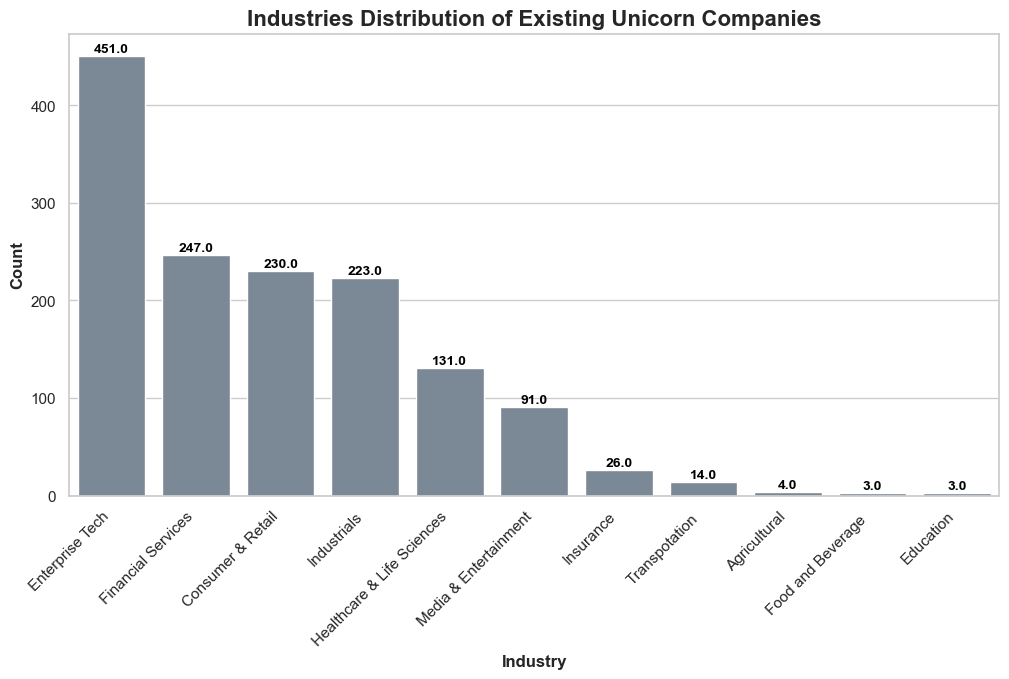

```python
# Sort the data by count in descending order
sorted_df = existing_df_3['Industry'].value_counts().reset_index().rename(columns={'index': 'Industry', 'Industry': 'Count'})
sorted_df = sorted_df.sort_values(by='Count', ascending=False)

# Create a bar chart
plt.figure(figsize=(12, 6))
sns.set(style="whitegrid")  # Set the style of the plot

ax = sns.barplot(data=sorted_df, x='Industry', y='Count', color="lightslategrey")

plt.title('Industries Distribution of Existing Unicorn Companies', fontsize=16, fontweight='bold')
plt.xlabel('Industry', fontsize=12, fontweight='bold')
plt.ylabel('Count', fontsize=12, fontweight='bold')

plt.xticks(rotation=45, ha='right')  # Rotate x-axis labels for better visibility

# Add counts to the bars
for p in ax.patches:
    ax.annotate(f'{p.get_height()}', (p.get_x() + p.get_width() / 2., p.get_height()),
                ha='center', va='center', fontsize=10, color='black', fontweight='bold', xytext=(0, 5),
                textcoords='offset points')

plt.show()
```

### Bivariate Analysis:

#### Exited Unicorn Companies

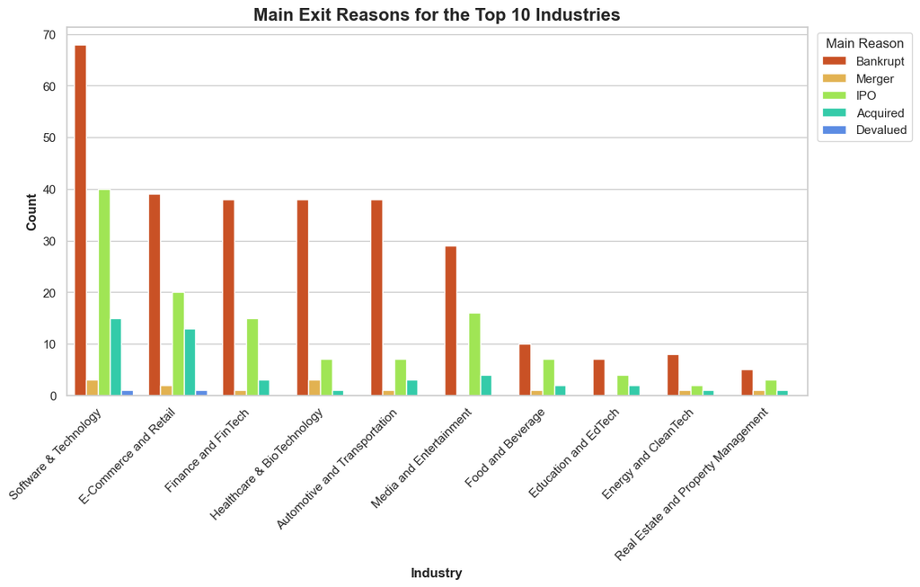

```python
# Assuming you want to plot a count of each industry in a column called 'Top Industries'
top_industries = exited_df_3['Main Industry'].value_counts().nlargest(10).index

# Filter the dataframe to include only the top 10 industries
df_top_industries = exited_df_3[exited_df_3['Main Industry'].isin(top_industries)]

# Create a bar chart with hue='Main Reason'
plt.figure(figsize=(12, 6))
sns.set(style="whitegrid")  # Set the style of the plot

ax = sns.countplot(data=df_top_industries, x='Main Industry', hue='Main Reason', palette='turbo_r', order=top_industries)

plt.title('Main Exit Reasons for the Top 10 Industries', fontsize=16, fontweight='bold')
plt.xlabel('Industry', fontsize=12, fontweight='bold')
plt.ylabel('Count', fontsize=12, fontweight='bold')

plt.xticks(rotation=45, ha='right')  # Rotate x-axis labels for better visibility

# Remove counts from the bars
for p in ax.patches:
    ax.annotate('', (p.get_x() + p.get_width() / 2., p.get_height()),
                ha='center', va='center', fontsize=10, color='black', fontweight='bold', xytext=(0, 5),
                textcoords='offset points')

plt.legend(title='Main Reason', title_fontsize='12', loc='upper right', bbox_to_anchor=(1.15, 1))

plt.show()
```

According to the above chart, bankruptcy is the reason for the company's exit in all of the top ten industries of the exited unicorn companies. The second most important reason for an IPO. Only unicorn companies in the software and technology industries, as well as the e-commerce and retail industries, have exited due to devaluation.

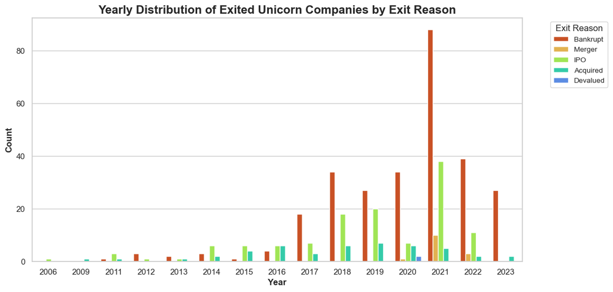

```python
# Create a stacked bar chart
plt.figure(figsize=(12, 6))
sns.set(style="whitegrid")  # Set the style of the plot

# Assuming you want to plot a count of each company in a column called 'Exit_Reason' stacked by 'Year'
ax = sns.countplot(data=exited_df_3, x='Year', hue='Main Reason', palette='turbo_r', dodge=True)

plt.title('Yearly Distribution of Exited Unicorn Companies by Exit Reason', fontsize=16, fontweight='bold')
plt.xlabel('Year', fontsize=12, fontweight='bold')
plt.ylabel('Count', fontsize=12, fontweight='bold')

plt.legend(title='Exit Reason', title_fontsize='12', fontsize='10', bbox_to_anchor=(1.05, 1), loc='upper left')

plt.show()
```

#### Emerging Unicorn Companies

```python
# Assuming 'Emerging_Companies.csv' has columns 'Lead Investors Include' and 'Country'
emerging_df_3 = pd.read_csv("Emerging_Companies.csv", encoding='unicode_escape')

# Splitting the 'InvestorColumn' and creating new rows
investor_list = emerging_df_3['Lead Investors Include'].str.split(', ')
investor_df = pd.DataFrame({
    'Investor': investor_list.sum(),  # Flatten the list of lists
    'Country': emerging_df_3['Country'].repeat(investor_list.apply(len))
})

# Counting the number of investors for each country
investor_counts = investor_df.groupby('Country').count().reset_index()

# Renaming the columns for clarity
investor_counts.columns = ['Country', 'Investor_Count']

# Display the result
print(investor_counts)
```

```
            Country  Investor_Count
0         Australia               3
1           Bahrain               2
2            Brazil               5
3            Canada              12
4             China              51
5          Colombia               2
6           Estonia               2
7           Finland               1
8            France               5
9           Germany              11
10        Hong Kong               3
11          Hungary               1
12            India              57
13        Indonesia               4
```

[output cut: 19 more lines]

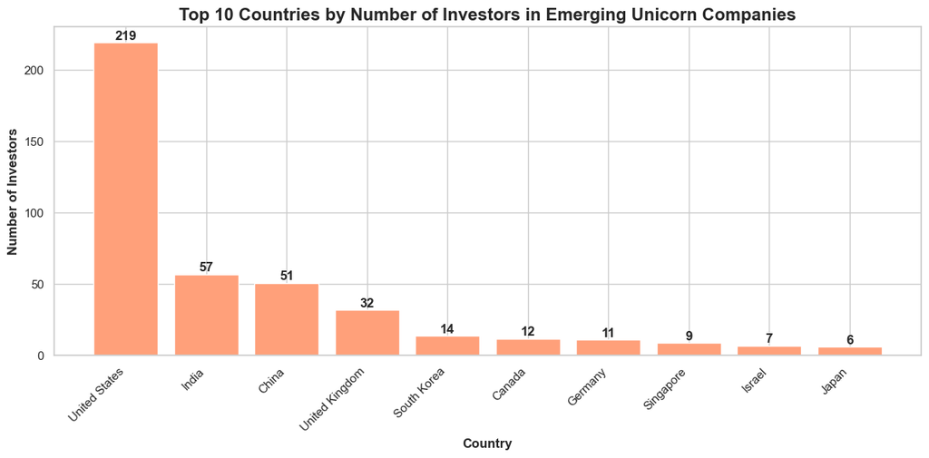

```python
# Selecting the top 10 countries
top_10_countries = investor_counts.sort_values(by='Investor_Count', ascending=False).head(10)

# Creating a bar chart with count values on top
plt.figure(figsize=(12, 6))
sns.set(style="whitegrid")
bars = plt.bar(top_10_countries['Country'], top_10_countries['Investor_Count'], color='lightsalmon')
plt.xlabel('Country', fontsize=12, fontweight='bold')
plt.ylabel('Number of Investors', fontsize=12, fontweight='bold')
plt.title('Top 10 Countries by Number of Investors in Emerging Unicorn Companies', fontsize=16, fontweight='bold')
plt.xticks(rotation=45, ha='right')  # Rotate x-axis labels for better readability

# Adding count values on top of the bars
for bar in bars:
    yval = bar.get_height()
    plt.text(bar.get_x() + bar.get_width() / 2, yval + 0.1, round(yval, 1), ha='center', va='bottom', fontweight='bold')

plt.tight_layout()

# Display the bar chart
plt.show()
```

#### Existing Unicorn Companies

```python
# Assuming 'Emerging_Companies.csv' has columns 'Lead Investors Include' and 'Country'
existing_df_3 = pd.read_csv("Unicorn_Companies.csv", encoding='unicode_escape')

# Splitting the 'InvestorColumn' and creating new rows
investor_list = existing_df_3['Lead Investors Include'].str.split(', ')
investor_df = pd.DataFrame({
    'Investor': investor_list.sum(),  # Flatten the list of lists
    'Country': existing_df_3['Country'].repeat(investor_list.apply(len))
})

# Counting the number of investors for each country
investor_counts = investor_df.groupby('Country').count().reset_index()

# Renaming the columns for clarity
investor_counts.columns = ['Country', 'Investor_Count']

# Display the result
print(investor_counts)
```

```
                 Country  Investor_Count
0              Argentina               2
1              Australia              19
2                Austria               4
3                Belgium               5
4                Bermuda               9
5                 Brazil              28
6             California               1
7                 Canada              38
8         Cayman Islands               1
9                  Chile               2
10                 China             419
11              Colombia               3
12               Croatia               2
13        Czech Republic               1
```

[output cut: 44 more lines]

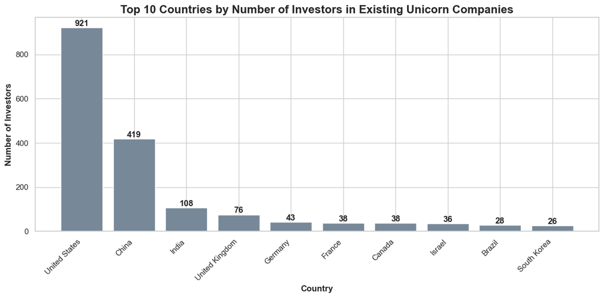

```python
# Selecting the top 10 countries
top_10_countries = investor_counts.sort_values(by='Investor_Count', ascending=False).head(10)

# Creating a bar chart with count values on top
plt.figure(figsize=(12, 6))
bars = plt.bar(top_10_countries['Country'], top_10_countries['Investor_Count'], color='lightslategrey')
plt.xlabel('Country', fontsize=12, fontweight='bold')
plt.ylabel('Number of Investors', fontsize=12, fontweight='bold')
plt.title('Top 10 Countries by Number of Investors in Existing Unicorn Companies', fontsize=16, fontweight='bold')
plt.xticks(rotation=45, ha='right')  # Rotate x-axis labels for better readability

# Adding count values on top of the bars
for bar in bars:
    yval = bar.get_height()
    plt.text(bar.get_x() + bar.get_width() / 2, yval + 0.1, round(yval, 1), ha='center', va='bottom', fontweight='bold')

plt.tight_layout()

# Display the bar chart
plt.show()
```

```python
import pandas as pd

# Splitting the 'InvestorColumn' and creating new rows
investor_list = existing_df_3['Lead Investors Include'].str.split(', ')
investor_df = pd.DataFrame({
    'Investor': investor_list.sum(),
    'Company': existing_df_3['Company'].repeat(investor_list.apply(len))
})

# Display the result
print(investor_df.reset_index(drop=True))
```

```
                          Investor           Company
0                           Google      Reliance Jio
1                              GIC         Ant Group
2                 Temasek Holdings         Ant Group
3                           Altria              JUUL
4                        Microsoft            OpenAI
...                            ...               ...
1984             CCB International     Wellong Etown
1985  China Structural Reform Fund            Xiaodu
1986                 Alibaba Group          Zhipu AI
1987                       Tencent          Zhipu AI
1988                 Baidu Capital  Zhiyuan Robotics

[1989 rows x 2 columns]
```

```python
# Counting the number of investors for each country
investor_counts = investor_df.groupby('Company').count().reset_index()

# Renaming the columns for clarity
investor_counts.columns = ['Company', 'Investor_Count']

# Display the result
print(investor_counts)
```

```
              Company  Investor_Count
0               01.AI               1
1          1047 Games               1
2               1KMXC               1
3            1Komma5°               1
4           1Password               1
...               ...             ...
1483          stc pay               1
1484  thatgamecompany               2
1485     unico IDtech               2
1486      v2 Ventures               1
1487            wefox               1

[1488 rows x 2 columns]
```

```python
# Assuming you have the 'investor_counts' DataFrame
investor_counts_column = investor_counts['Investor_Count']

# Get the count of each unique value
count_of_each_unique_value = investor_counts_column.value_counts()

print("Count of each unique Investor_Count value:")
print(count_of_each_unique_value)
```

```
Count of each unique Investor_Count value:
1     1070
2      396
4        6
3        4
10       3
5        3
7        2
6        2
9        1
11       1
Name: Investor_Count, dtype: int64
```

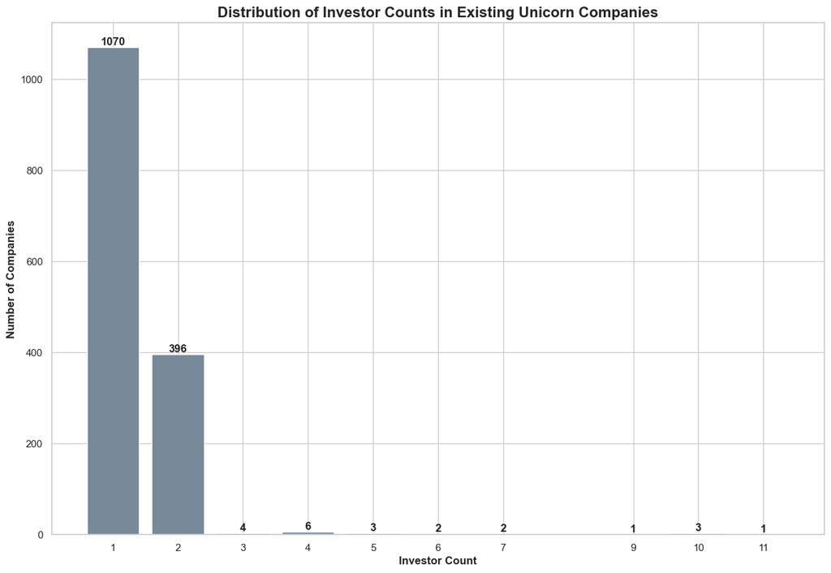

```python
# Assuming you have the 'investor_counts' DataFrame
investor_counts_column = investor_counts['Investor_Count']

# Get the count of each unique value
count_of_each_unique_value = investor_counts_column.value_counts()

# Increase the size of the plot
plt.figure(figsize=(15, 10))

# Plotting the bar chart
bars = plt.bar(count_of_each_unique_value.index, count_of_each_unique_value.values, color='lightslategrey')

# Adding counts on top of the bars
for bar in bars:
    yval = bar.get_height()
    plt.text(bar.get_x() + bar.get_width()/2, yval + 0.1, round(yval, 1), ha='center', va='bottom', fontweight='bold')

# Adding labels and title
plt.xlabel('Investor Count', fontsize=12, fontweight='bold')
plt.ylabel('Number of Companies', fontsize=12, fontweight='bold')
plt.title('Distribution of Investor Counts in Existing Unicorn Companies', fontsize=16, fontweight='bold')

# Adding labels to each tick on the x-axis
plt.xticks(count_of_each_unique_value.index, count_of_each_unique_value.index)

# Display the plot
plt.show()
```

Eventhough there are 1490 companies here the total count of companies is 1488, considering that there are two countries with identical names in the company list. It's important to note that these entries are not duplicates; rather, they represent two distinct companies with similar names. Despite the name similarity, they are separate entities.

[figure not shown]

### Multivariate Analysis:

Connection between number of investors in a country and the number of startups

#### Existing Unicorn Companies

```python
# Assuming 'Emerging_Companies.csv' has columns 'Lead Investors Include' and 'Country'
existing_df_3 = pd.read_csv("Unicorn_Companies.csv", encoding='unicode_escape')

# Splitting the 'Lead Investors Include' column and creating new rows
investor_list = existing_df_3['Lead Investors Include'].str.split(', ')
investor_df = pd.DataFrame({
    'Investor': investor_list.sum(),  # Flatten the list of lists
    'Country': existing_df_3['Country'].repeat(investor_list.apply(len))
})

# Counting the number of investors for each country
investor_counts = investor_df.groupby('Country').count().reset_index()
investor_counts.columns = ['Country', 'Investor_Count']

# Counting the number of companies for each country
company_counts = existing_df_3['Country'].value_counts().reset_index()
company_counts.columns = ['Country', 'Company_Count']

# Merging the two dataframes on the 'Country' column
result_df = pd.merge(investor_counts, company_counts, on='Country', how='outer').fillna(0)

# Display the result
print(result_df)
```

```
                 Country  Investor_Count  Company_Count
0              Argentina               2              1
1              Australia              19             11
2                Austria               4              3
3                Belgium               5              3
4                Bermuda               9              1
5                 Brazil              28             20
6             California               1              1
7                 Canada              38             27
8         Cayman Islands               1              1
9                  Chile               2              2
10                 China             419            275
11              Colombia               3              2
12               Croatia               2              1
13        Czech Republic               1              1
```

[output cut: 44 more lines]

[figure not shown]

```python
df = pd.DataFrame(result_df)

# Sorting by Investor_Count for better visualization
df = df.sort_values('Investor_Count', ascending=False)

# Selecting the top 10 countries
df_top10 = df.head(10)

# Plotting
fig, ax1 = plt.subplots(figsize=(14, 8))

color = 'red'
ax1.set_xlabel('Country', fontsize=12, fontweight='bold')
ax1.set_ylabel('Investor Count', color=color, fontsize=12, fontweight='bold')
ax1.plot(df_top10['Country'], df_top10['Investor_Count'], color=color, marker='o', label='Investor Count')
ax1.tick_params(axis='y', labelcolor=color)
plt.xticks(rotation=45, ha='right')

ax2 = ax1.twinx()  # instantiate a second axes that shares the same x-axis

color = 'blue'
ax2.set_ylabel('Company Count', color=color, fontsize=12, fontweight='bold')  # we already handled the x-label with ax1
ax2.bar(df_top10['Country'], df_top10['Company_Count'], color=color, alpha=0.5, label='Company Count')
ax2.tick_params(axis='y', labelcolor=color)

fig.tight_layout()  # otherwise the right y-label is slightly clipped
plt.title('Top 20 Investor and Company Count by Country', fontsize=16, fontweight='bold')
plt.show()
```

The graph above demonstrates that as the number of companies in every country declines, so does the number of investors.